# Douleur Chronique : typologies de parcours de soins et caractérisation des profils patients

Projet eDOL

Armel Soubeiga - LIMOS

2023-04-24

# Contexte

[figure not shown]

Le parcours de santé des patients souffrant de douleur chronique est multiple ce qui entraîne des résultats médiocres en terme d’amélioration de leur santé.

L’identification des profils de ces patients permettrait aux corps médical d’améliorer les résultats de soins et de mieux soutenir ces patients. Nous proposons une approche par regroupement des typologies de parcours de soins et d’identification des profils.

# Approche

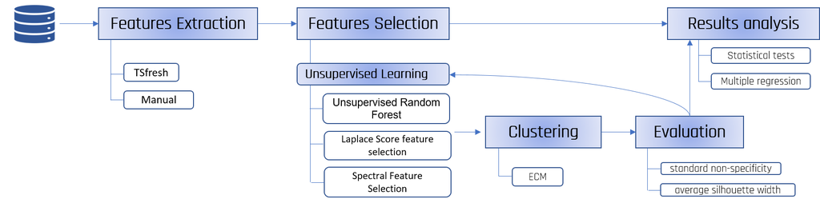

# Analyses descriptives des barométriques

- Auto-questionnaires: des données évaluant les symptômes, les comorbidités et les états psychologiques et physiologiques liés à la douleur chronique. Ces questionnaires sont remplis trimestriellement ou semestriellement par le patient.
- Questionnaires personnels: des données socio-démographiques, de comportement de vie et professionnelles, remplies une seule fois par le patient à l’inclusion dans l’étude.
- Questionnaires barométriques d’évaluation de la douleur, la fatigue, le moral, le stress, le sommeil, le confort corporel, l’activité sportive et non-sportive. Ces données sont collectées hebdomadairement.

|  | douleur | stress | fatigue | sommeil | moral | confort_corpo | act_non_sport | act_sport |
| --- | --- | --- | --- | --- | --- | --- | --- | --- |
| vars | 1.00 | 2.00 | 3.00 | 4.00 | 5.00 | 6.00 | 7.00 | 8.00 |
| n | 14856.00 | 14856.00 | 14856.00 | 14856.00 | 14856.00 | 14856.00 | 14856.00 | 14856.00 |
| mean | 6.11 | 4.36 | 6.19 | 5.02 | 5.97 | 4.59 | 5.76 | 4.22 |
| sd | 2.07 | 2.53 | 2.26 | 2.34 | 2.28 | 2.00 | 3.27 | 3.47 |
| min | 0.00 | 0.00 | 0.00 | 0.00 | 0.00 | 0.00 | 0.00 | 0.00 |
| max | 10.00 | 10.00 | 10.00 | 10.00 | 10.00 | 10.00 | 10.00 | 10.00 |
| range | 10.00 | 10.00 | 10.00 | 10.00 | 10.00 | 10.00 | 10.00 | 10.00 |
| se | 0.02 | 0.02 | 0.02 | 0.02 | 0.02 | 0.02 | 0.03 | 0.03 |
| Q0.25 | 5.00 | 2.00 | 5.00 | 3.00 | 4.00 | 3.00 | 3.00 | 1.00 |
| Q0.75 | 8.00 | 6.00 | 8.00 | 7.00 | 8.00 | 6.00 | 10.00 | 7.00 |

Tendance : en moyenne, les scores pour la douleur et la fatigue sont relativement élevés, tandis que les scores pour le stress et l’activité sportive sont relativement bas.

Dispersion : Selon l’sd, l’activité sportive et non-sportive sontrelativement plus dispersées que les autres barométre. Donc ces variables auront un effet dominant par rapport aux autres.

Visualisation des baromètres

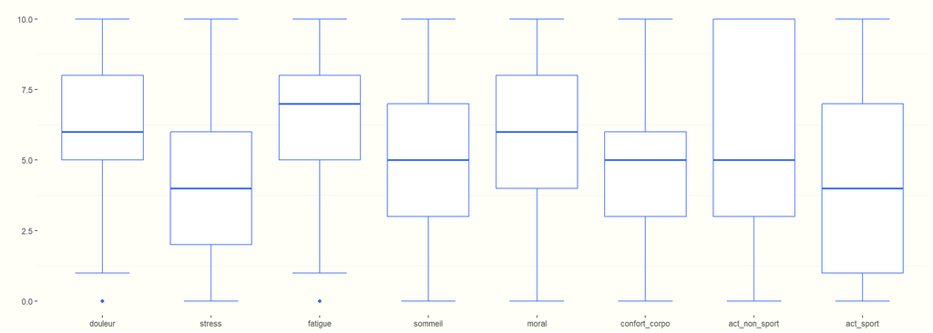

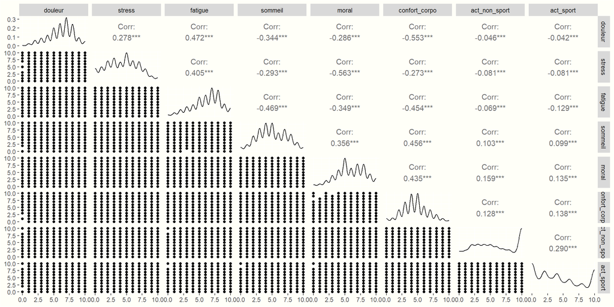

# Transformation et sélection des caratéristiques des barométriques

Nous avons comparé deux algorithmes de sélection non supervisés (unsupervised selection) de variables. En se basant sur la méthode du coude (elbow method) sur les courbes de performance, nous avons puis identifier 7 sélections optimales pour chaque algorithme.

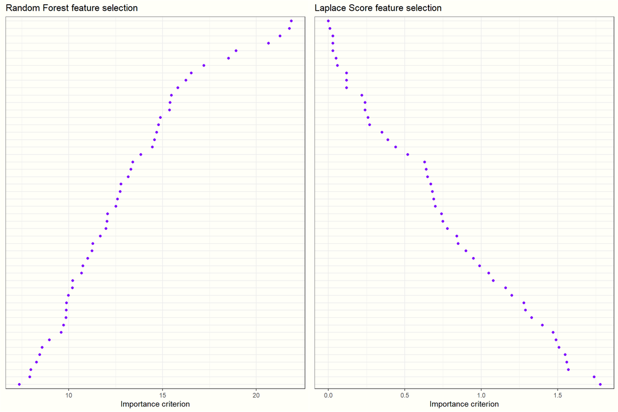

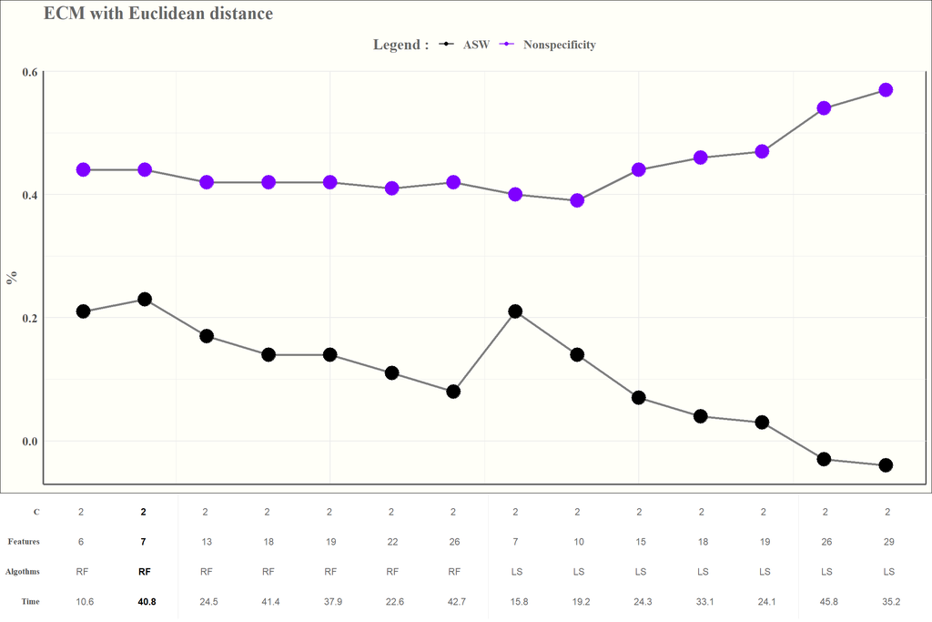

# Clustering des parcours de soins

## Parametres du modèle

```
## ------ Credal partition ------
## 2 classes,664 objects
## Generated by ecm
## Focal sets:
##      [,1] [,2]
## [1,]    0    0
## [2,]    1    0
## [3,]    0    1
## [4,]    1    1
## Value of the criterion = 6604.73
## Nonspecificity = 0.44
## Prototypes:
##           [,1]      [,2]      [,3]      [,4]      [,5]       [,6]      [,7]
## [1,] -1.681774  1.329505 -1.050635 -1.194495  1.364064  0.9961076 -1.943622
## [2,]  1.969674 -1.559476  1.234187  1.397568 -1.594378 -1.1691879  2.271797
## Number of outliers = 0.00
```

```
## [1] "Sommeil__mean"          "Fatigue__mean"          "Confort.corporel__mean"
## [4] "Moral__mean"            "Stress__mean"           "Douleur__mean"
## [7] "Sommeil__median"
```

## Les statistiques du modèle ECM

|  | cl_1 | cl_2 | Cl_incertains |
| --- | --- | --- | --- |
| cluster.size | 216.00 | 157.00 | 291.00 |
| noisen | 0.00 | 0.00 | 0.00 |
| diameter | 27.84 | 29.12 | 28.92 |
| average.distance | 9.12 | 9.96 | 8.61 |
| clus.avg.silwidths | 0.22 | 0.23 | 0.23 |
| dunn | 0.04 | 0.04 | 0.04 |

## Etude de la silhoutte

L’analyse de silhouette mesure la qualité du regroupement d’une observation et estime la distance moyenne entre les regroupements :

- Une valeur proche de 1 indique que l’objet est bien groupé. Autrement dit, l’objet est similaire aux autres objets de son groupe.
- Une valeur de proche de -1 indique que l’objet est mal regroupé et que l’affectation à un autre cluster améliorerait probablement les résultats globaux.

```
##   cluster size ave.sil.width
## 1       1  216          0.22
## 2       2  157          0.23
## 3       3  291          0.23
```

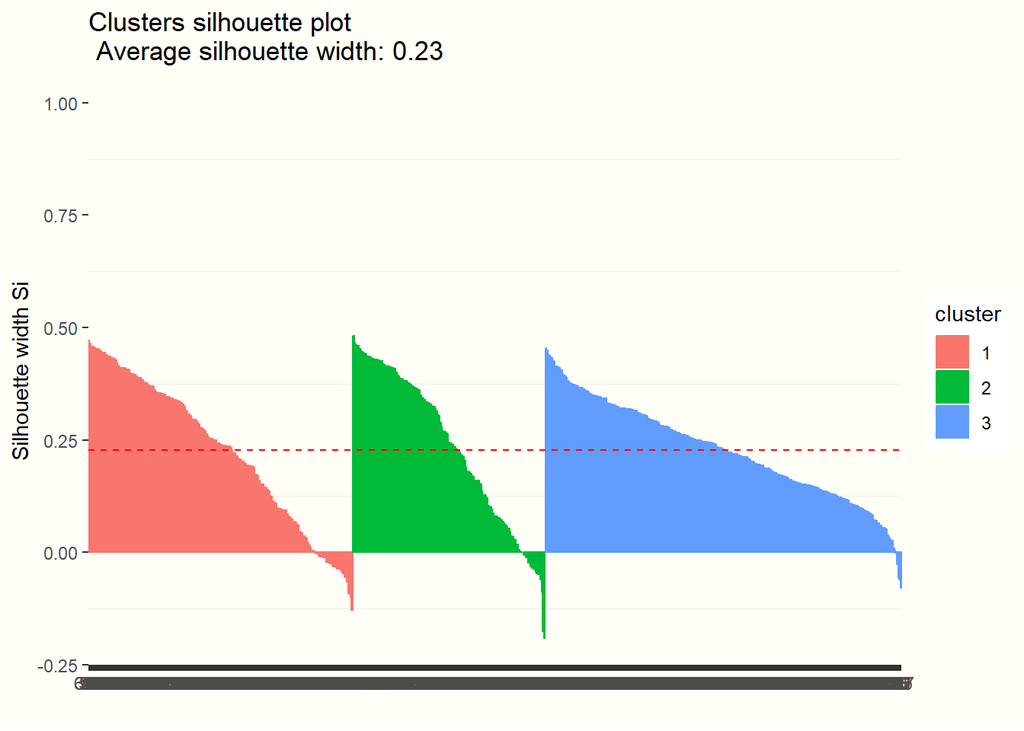

On constate que plusieurs observations, ont un coefficient de silhouette négatif. Cela signifie qu’ils ne sont pas dans le bon cluster.

## Les patients à silhouette négative

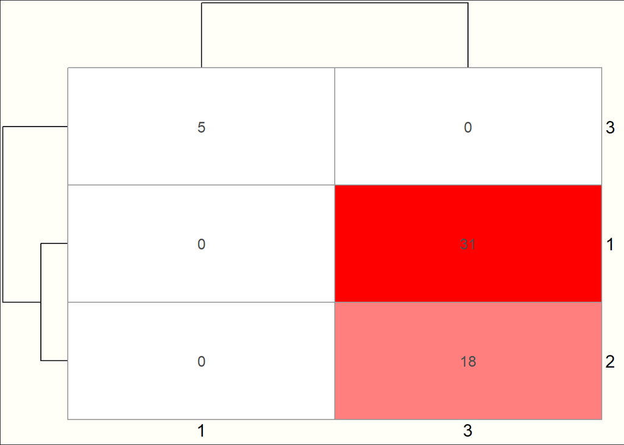

## Visualisation des typologies

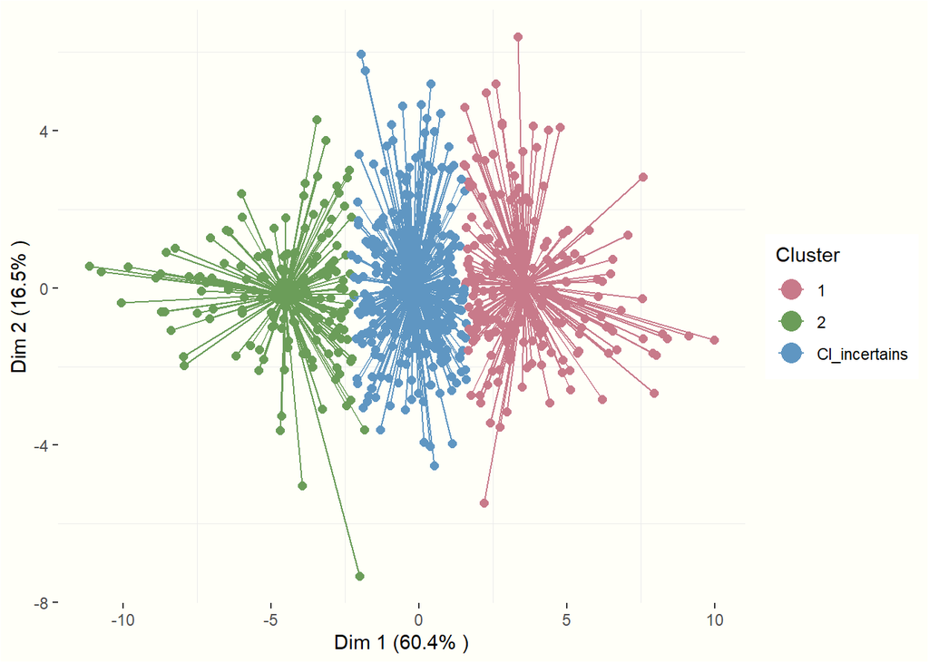

## Visualisation des typologies sur l’ACP

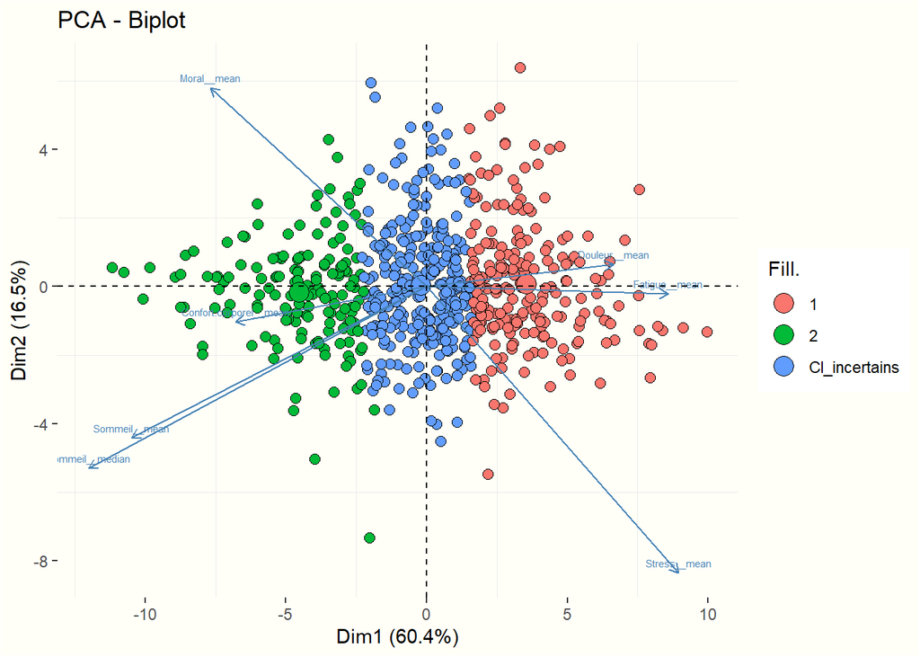

## Visualisation hiérarchique des clusters

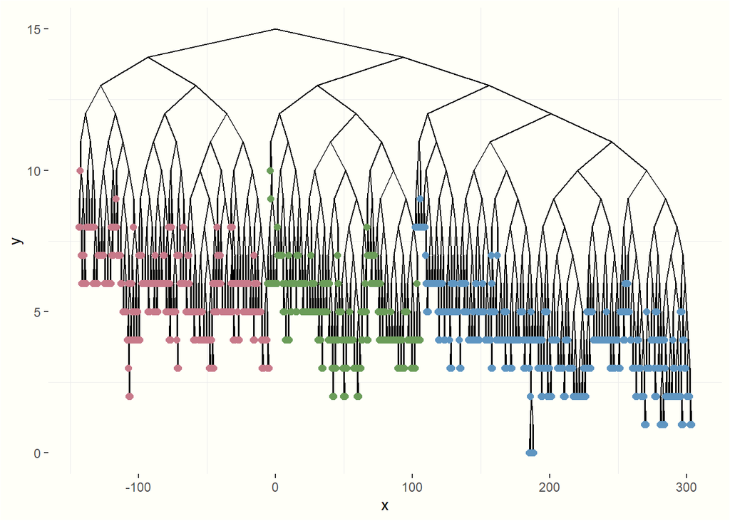

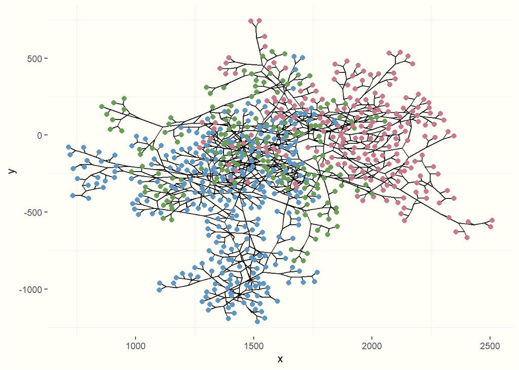

# Analyse de l’impact du clusters incertaines sur la qualité du clustering

## Analyse avancée de la silhoutte

```
##   cluster size ave.sil.width
## 1       1  216          0.57
## 2       2  157          0.53
```

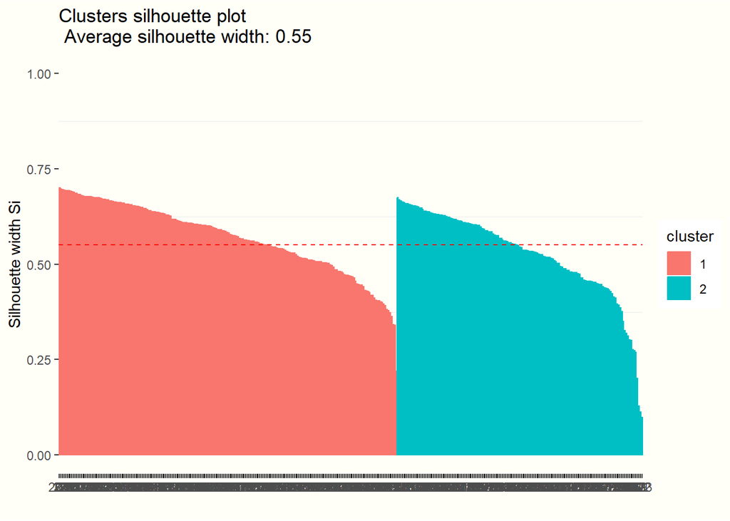

## Analyse de la stabilité

| stat | ECM_incertain_set | ECM_without_incertain_set |
| --- | --- | --- |
| HGSD | 0.5898493 | 0.9230857 |
| ASW | 0.2267151 | 0.5512561 |

## Analyse de variance (ANOVA)

| **Characteristic** | **1**, N = 216<sup>1</sup> | **2**, N = 157<sup>1</sup> | **3**, N = 291<sup>1</sup> | **p-value**<sup>2</sup> |
| --- | --- | --- | --- | --- |
| Sommeil__mean | -1.54 (-2.32, -0.93) | 1.92 (1.39, 2.69) | 0.04 (-0.51, 0.71) | <0.001 |
| Fatigue__mean | 1.24 (0.66, 1.89) | -1.47 (-2.47, -0.79) | -0.04 (-0.81, 0.64) | <0.001 |
| Confort.corporel__mean | -0.96 (-1.69, -0.31) | 1.10 (0.56, 1.75) | 0.12 (-0.44, 0.65) | <0.001 |
| Moral__mean | -1.23 (-2.13, -0.39) | 1.33 (0.79, 2.10) | -0.07 (-0.73, 0.95) | <0.001 |
| Stress__mean | 1.37 (0.23, 2.28) | -1.63 (-2.66, -0.74) | 0.13 (-0.93, 1.00) | <0.001 |
| Douleur__mean | 1.05 (0.31, 1.71) | -1.01 (-2.19, -0.29) | 0.02 (-0.86, 0.73) | <0.001 |
| Sommeil__median | -1.73 (-2.73, -0.73) | 2.27 (1.27, 3.27) | 0.27 (-0.73, 0.27) | <0.001 |

<sup>1</sup> Median (IQR)  
<sup>2</sup> One-way ANOVA

| **Characteristic** | **1**, N = 216<sup>1</sup> | **2**, N = 157<sup>1</sup> | **p-value**<sup>2</sup> |
| --- | --- | --- | --- |
| Sommeil__mean | -1.54 (-2.32, -0.93) | 1.92 (1.39, 2.69) | <0.001 |
| Fatigue__mean | 1.24 (0.66, 1.89) | -1.47 (-2.47, -0.79) | <0.001 |
| Confort.corporel__mean | -0.96 (-1.69, -0.31) | 1.10 (0.56, 1.75) | <0.001 |
| Moral__mean | -1.23 (-2.13, -0.39) | 1.33 (0.79, 2.10) | <0.001 |
| Stress__mean | 1.37 (0.23, 2.28) | -1.63 (-2.66, -0.74) | <0.001 |
| Douleur__mean | 1.05 (0.31, 1.71) | -1.01 (-2.19, -0.29) | <0.001 |
| Sommeil__median | -1.73 (-2.73, -0.73) | 2.27 (1.27, 3.27) | <0.001 |

<sup>1</sup> Median (IQR)  
<sup>2</sup> One-way ANOVA

# La catégorisation des clusters

L’idée est de comparer les moyennes des variables actives conditionnellement aux clusters et en se basant sur l’explicabilité globale de chaque variables.

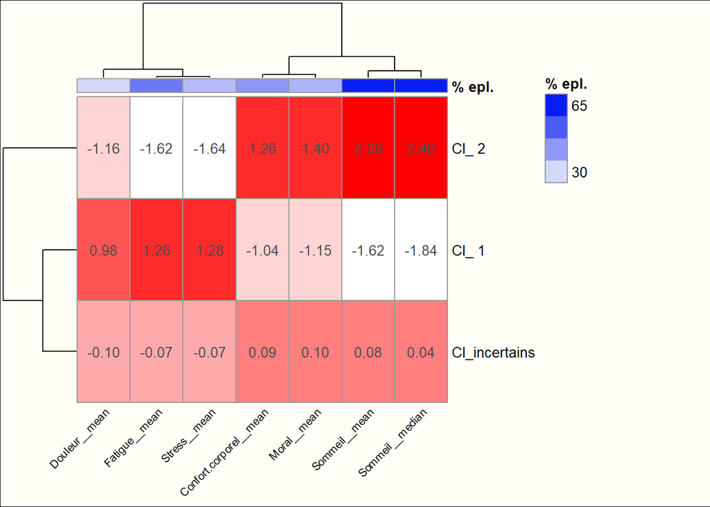

- Cluster 1 (cl_1) : Douleur chronique associée à la “Triade de l’inconfort” ou “Inconforts chroniques” (en référence à la Fatigue, au Stress et à la Douleur).
- Cluster 2 (cl_2) : Douleur chronique associée à la “Triade du bien-être” ou “Bien-être global chronique” (en référence au Sommeil, au Confort corporel et au Moral).
- Cluster intermédiaire

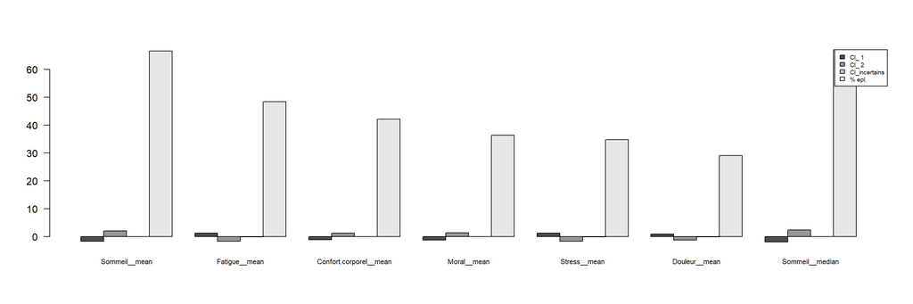

# Analyse descriptive des clusters

## Analyse descriptive des facteurs socio-demogaphiques

| **Variable** | **Cl_1**, N = 216<sup>1</sup> | **Cl_2**, N = 157<sup>1</sup> | **Cl_incertains**, N = 291<sup>1</sup> | **p-value**<sup>2</sup> |
| --- | --- | --- | --- | --- |
| Age |  |  |  | <0.001 |
| 18 et 30 ans excluss | 12 (5.6%) | 3 (1.9%) | 5 (1.7%) |  |
| 30 et 50 ans inclus | 179 (83%) | 113 (72%) | 237 (81%) |  |
| Plus 50 ans | 25 (12%) | 40 (26%) | 49 (17%) |  |
| Unknown | 0 | 1 | 0 |  |
| Nbr enfants |  |  |  | 0.11 |
| 1 et 2 enfants | 81 (38%) | 69 (44%) | 143 (49%) |  |
| Pas d'enfants | 108 (50%) | 74 (47%) | 118 (41%) |  |
| Plus 2 enfants | 27 (12%) | 14 (8.9%) | 30 (10%) |  |
| Niveau Etudes |  |  |  | 0.12 |
| Avancé | 32 (15%) | 32 (20%) | 64 (22%) |  |
| BAC | 54 (25%) | 34 (22%) | 54 (19%) |  |
| Intermédiaire | 67 (31%) | 57 (36%) | 86 (30%) |  |
| Secondaire | 63 (29%) | 34 (22%) | 87 (30%) |  |
| Profession |  |  |  | 0.12 |
| Avancé | 214 (99%) | 155 (99%) | 291 (100%) |  |
| Secondaire | 2 (0.9%) | 2 (1.3%) | 0 (0%) |  |
| Fumeur |  |  |  | 0.020 |
| Non | 150 (69%) | 129 (82%) | 219 (75%) |  |
| Oui | 66 (31%) | 28 (18%) | 72 (25%) |  |
| Alcoolémie |  |  |  | 0.043 |
| Non | 90 (42%) | 48 (31%) | 95 (33%) |  |
| Oui | 126 (58%) | 109 (69%) | 196 (67%) |  |
| Diagnostic |  |  |  | 0.4 |
| Non | 32 (15%) | 31 (20%) | 55 (19%) |  |
| Oui | 184 (85%) | 126 (80%) | 236 (81%) |  |
| Duree Douleur |  |  |  | 0.3 |
| Depuis plus de 10 ans | 72 (33%) | 47 (30%) | 109 (37%) |  |
| Entre 3 et 6 mois | 2 (0.9%) | 0 (0%) | 1 (0.3%) |  |
| Entre 5 et 10 ans | 53 (25%) | 34 (22%) | 60 (21%) |  |
| Entre 6 mois et 1 an | 14 (6.5%) | 14 (8.9%) | 18 (6.2%) |  |
| Environ 2 ans | 32 (15%) | 16 (10%) | 30 (10%) |  |
| Environ 3 ans | 15 (6.9%) | 23 (15%) | 22 (7.6%) |  |
| Environ 4 ans | 15 (6.9%) | 11 (7.0%) | 22 (7.6%) |  |
| Environ 5 ans | 12 (5.6%) | 12 (7.6%) | 28 (9.6%) |  |
| Moins de 3 mois | 1 (0.5%) | 0 (0%) | 1 (0.3%) |  |
| Frequence Douleur |  |  |  | <0.001 |
| Continue tout au long de la journée | 24 (11%) | 41 (26%) | 58 (20%) |  |
| Fréquente (plusieurs fois par semaine) | 11 (5.1%) | 19 (12%) | 29 (10.0%) |  |
| Permanente (le jour et la nuit) | 134 (62%) | 48 (31%) | 131 (45%) |  |
| Rare (moins d’une fois par semaine) | 1 (0.5%) | 3 (1.9%) | 1 (0.3%) |  |
| Très fréquente (tous les jours) | 46 (21%) | 46 (29%) | 72 (25%) |  |
| Duree Crises |  |  |  | 0.4 |
| Entre 1h et 2h | 31 (14%) | 14 (8.9%) | 45 (15%) |  |
| Entre 30 min et 1h | 31 (14%) | 25 (16%) | 40 (14%) |  |
| Moins de 30 min | 17 (7.9%) | 20 (13%) | 28 (9.6%) |  |
| Plus de 2h | 137 (63%) | 98 (62%) | 178 (61%) |  |
| Frequence Crises |  |  |  | <0.001 |
| Exceptionnelle (jamais ou presque jamais) | 1 (0.5%) | 13 (8.3%) | 3 (1.0%) |  |
| Fréquente (tous les jours) | 99 (46%) | 52 (33%) | 136 (47%) |  |
| Rare (pas tous les jours) | 37 (17%) | 60 (38%) | 74 (25%) |  |
| Très fréquente (plusieurs fois par jour) | 79 (37%) | 32 (20%) | 78 (27%) |  |
| Reveil Nuit |  |  |  | <0.001 |
| Au moins 1 fois par nuit | 44 (20%) | 23 (15%) | 65 (22%) |  |
| Jamais | 8 (3.7%) | 33 (21%) | 17 (5.8%) |  |
| Plusieurs fois par nuit | 104 (48%) | 25 (16%) | 88 (30%) |  |
| Quelquefois | 60 (28%) | 76 (48%) | 121 (42%) |  |
| Empeche Dormir |  |  |  | <0.001 |
| Jamais | 6 (2.8%) | 33 (21%) | 25 (8.6%) |  |
| Quelquefois | 81 (38%) | 79 (50%) | 137 (47%) |  |
| Souvent | 71 (33%) | 34 (22%) | 102 (35%) |  |
| Tous les soirs | 58 (27%) | 11 (7.0%) | 27 (9.3%) |  |
| Situation Famille |  |  |  | 0.4 |
| Célibataire | 79 (37%) | 45 (29%) | 84 (29%) |  |
| En couple | 133 (62%) | 109 (69%) | 199 (68%) |  |
| Veuve / Veuf | 4 (1.9%) | 3 (1.9%) | 8 (2.7%) |  |
| Genre |  |  |  | 0.13 |
| Autres | 1 (0.5%) | 1 (0.6%) | 0 (0%) |  |
| Feminin | 183 (85%) | 120 (76%) | 241 (83%) |  |
| Masculin | 32 (15%) | 36 (23%) | 50 (17%) |  |

<sup>1</sup> n (%)  
<sup>2</sup> Fisher's Exact Test for Count Data with simulated p-value (based on 2000 replicates); Pearson's Chi-squared test

## Analyse descriptive des facteurs cliniques

Pour prendre en compte les mesures répétées des variables explicatives au fil du temps, nous utilisons les tests adaptés suivants :

- Kruskal-Wallis Test pour les variables quantitatives. Le test de Kruskal-Wallis est une alternative non paramétrique au test t pour comparer plus de deux échantilllons appariés.
- Fisher’s exact test ou Friedman Rank Sum Test. Le test de Friedman est une alternative non paramétrique au test ANOVA unidirectionnel à mesures répétées. Il étend le test du signe dans la situation où il y a plus de deux groupes à comparer.

| **Variable** | **N**<sup>1</sup> | **Cl_1**, N = 352<sup>2</sup> | **Cl_2**, N = 308<sup>2</sup> | **Cl_incertains**, N = 514<sup>2</sup> | **p-value**<sup>3</sup> |
| --- | --- | --- | --- | --- | --- |
| Catastrophisme | 1,173 |  |  |  | <0.001 |
| Catastrophisme avere |  | 168 (48%) | 66 (21%) | 159 (31%) |  |
| Catastrophisme non-avere |  | 183 (52%) | 242 (79%) | 355 (69%) |  |
| Kinésiophobie | 1,181 |  |  |  | <0.001 |
| Kinesiophobie avere |  | 260 (73%) | 167 (54%) | 331 (64%) |  |
| Kinesiophobie non-avere |  | 98 (27%) | 140 (46%) | 185 (36%) |  |
| Croyance et perception Culpabilite | 783 |  |  |  | <0.001 |
| Douleur culpabilité |  | 211 (85%) | 122 (64%) | 250 (73%) |  |
| Douleur non-culpabilité |  | 38 (15%) | 70 (36%) | 92 (27%) |  |
| Croyance et perception Mystere | 783 |  |  |  | 0.004 |
| Douleur mystère |  | 217 (87%) | 144 (75%) | 287 (84%) |  |
| Douleur non-mystère |  | 32 (13%) | 48 (25%) | 55 (16%) |  |
| Croyance et perception Perenite | 783 |  |  |  | <0.001 |
| Douleur non-peréne |  | 65 (26%) | 92 (48%) | 136 (40%) |  |
| Douleur peréne |  | 184 (74%) | 100 (52%) | 206 (60%) |  |
| Croyance et perception Constance | 783 |  |  |  | 0.001 |
| Douleur constant |  | 43 (17%) | 12 (6.2%) | 43 (13%) |  |
| Douleur non-constant |  | 206 (83%) | 180 (94%) | 299 (87%) |  |
| Personnalité Ouvert d'esprit, Originalité | 662 | 3.04 (0.82) | 3.16 (0.88) | 3.04 (0.78) | 0.4 |
| Personnalité Névrotique, Négatif | 662 | 4.07 (0.56) | 4.31 (0.49) | 4.13 (0.51) | <0.001 |
| Personnalité de nature Conscience, Contrôle, Contrainte | 662 | 3.97 (0.64) | 4.20 (0.58) | 4.01 (0.57) | <0.001 |
| Personnalité de nature Agréable, Altruiste | 662 | 3.61 (0.82) | 3.03 (0.84) | 3.38 (0.82) | <0.001 |
| Personnalité de nature Enthousiasme, Extraverti | 662 | 3.54 (0.72) | 3.52 (0.69) | 3.50 (0.68) | 0.8 |
| Alexithymie | 662 |  |  |  | <0.001 |
| Alexithymie avere |  | 137 (64%) | 60 (38%) | 146 (50%) |  |
| Alexithymie non-avere |  | 78 (36%) | 97 (62%) | 144 (50%) |  |
| Orientation de vie : optimiste | 656 | 11.52 (2.03) | 12.55 (2.27) | 11.95 (2.04) | <0.001 |
| Croyance justice : sa douleur est une injustice | 656 | 16.4 (4.1) | 18.4 (4.4) | 17.3 (4.1) | <0.001 |
| Injustice : sa douleur est une injustice | 787 | 17.2 (4.6) | 13.6 (5.4) | 15.6 (4.8) | <0.001 |
| Dépression | 1,180 |  |  |  | <0.001 |

[output cut: 61 more lines]

<sup>1</sup> N not Missing  
<sup>2</sup> Mean(sd) or n(%)  
<sup>3</sup> Fisher's Exact Test for Count Data with simulated p-value (based on 2000 replicates)

# Identification des profils patients

- La régression logistique multinomiale permettra d’isoler les effets de chaque variable explicative, c’est-à-dire d’identifier les effets résiduels sur l’appartennance aux clusters. Et pour les variables à plusieurs occurances, nous utiliserons les modèles logistique multinomiale mixtes.
- Sélection de modèles: La phase des tests statistiques ont permis de selectionner les variables qui expliquent significativement l’appartennance à un cluster. Mais cette analyse ne prend pas en compte l’interraction multi-dimension. Et cette interaction peux induire une selection de modèle. Ici on se base sur le critère **AIC**.

## Profils socio-démographiques

```
## Likelihood ratio tests of Multinomial Models
##
## Response: Cluster
##                                                                                                              Model
## 1                                                            age + frequence_crises + reveil_nuit + empeche_dormir
## 2 age + tabac_nb_cig_jour + alcool_frequence + frequence_douleur + frequence_crises + reveil_nuit + empeche_dormir
##   Resid. df Resid. Dev   Test    Df LR stat.   Pr(Chi)
## 1      1302   1276.181
## 2      1290   1264.305 1 vs 2    12 11.87582 0.4557038
```

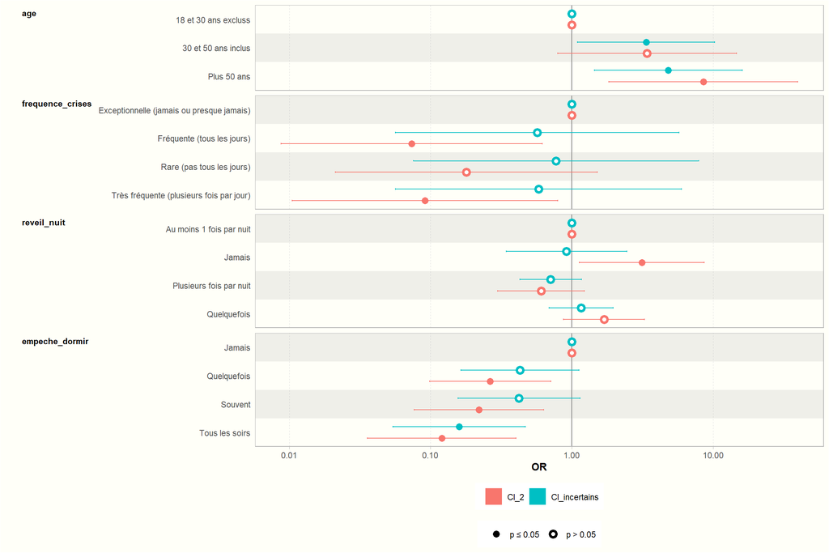

## Profils sur la perception de la douleur

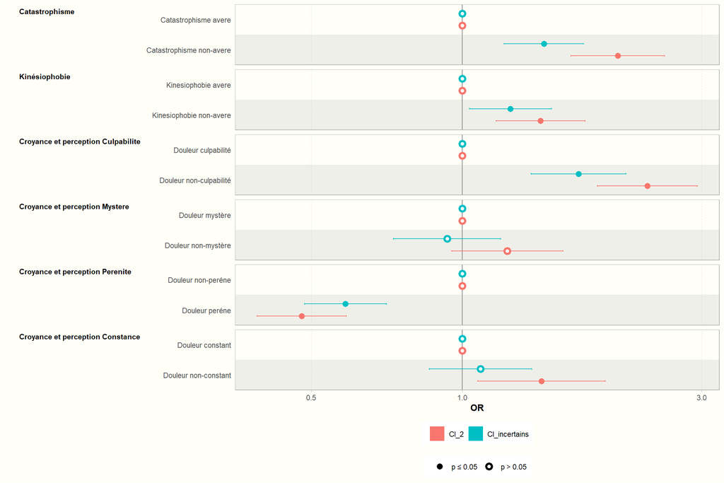

## Profils Psychologie

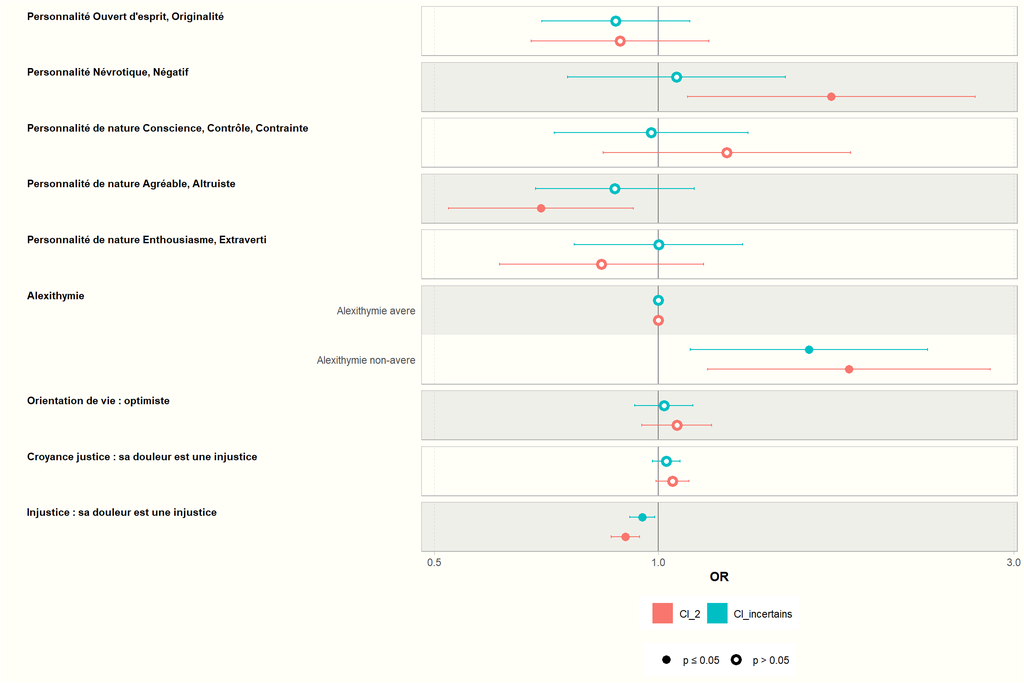

## Profils selon les Comorbidités

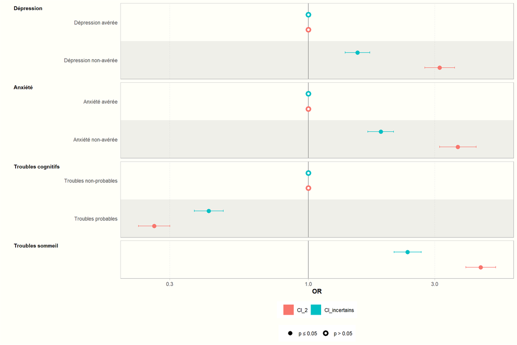

## Profils selon la Qualité de vie du patient

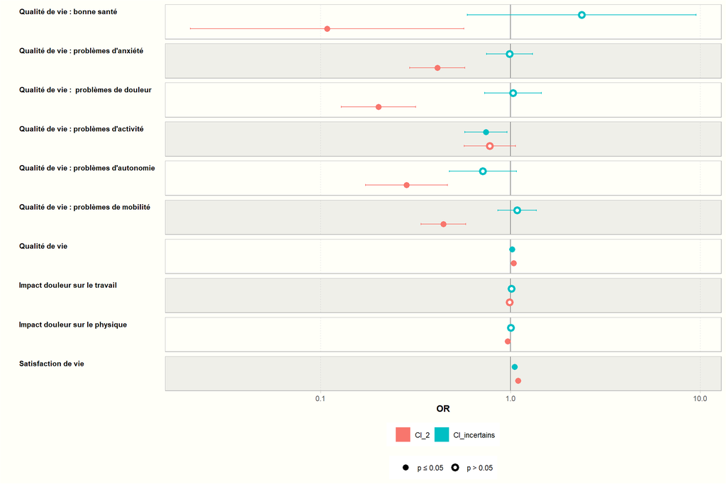

## D’autres profils

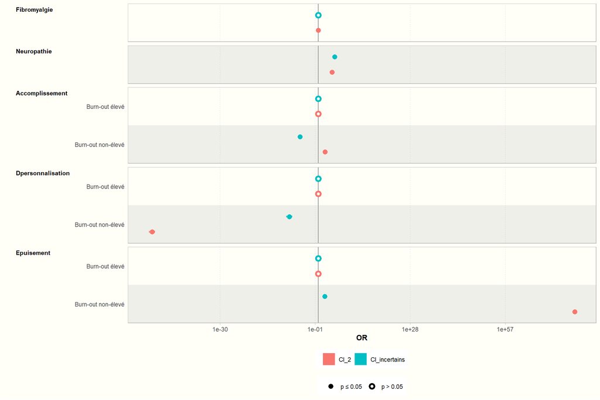